# compstatsR: C++ and Rcpp

19 March 2026

## When to use C++

## Don’t (from [Rich Fitzjohn](https://github.com/richfitz/rc2016/blob/master/slides.md))

- Slower development
- Have to learn/remember two languages
- Profiling is harder
- Debugging is harder
- Platform independence is harder
- Distributing code is harder

## Instead

- optimize and profile
- use existing library code
- check algorithms  
  (FitzJohn: “Using C will not magically make a bad algorithm faster”)

## Why *should* you?

- Proven need for speed
- Very large objects: avoid copying
- Linking to external software libraries

> Typical bottlenecks that C++ can address include:
> - Loops that can’t be easily vectorised because subsequent iterations depend on previous ones.
> - Recursive functions, or problems which involve calling functions millions of times. The overhead of calling a function in C++ is much lower than that in R.
> - Problems that require advanced data structures and algorithms that R doesn’t provide …

## C++ super-basics

## C++ vs. R

C++ is:

- older
- [much more widely used](https://www.tiobe.com/tiobe-index/)  
  (in 2026: #3 after Python and C, R is #9)
- lower-level (“close to the metal”)
- strongly object-oriented …
- superset of (simpler) C
- compiled rather than interpreted

## C++ differences from R

- syntax
  - statements end with semicolons
- zero-indexing
- stronger/static typing
  - variable declaration
  - scalars and vectors are different

## example (Wickham (2019))

```r
library(Rcpp)
cppFunction(
 'int subtract(int x, int y) {
    int diff = x - y;
    return diff;
  }')
subtract(4,5)
```

```
## [1] -1
```

```r
subtract(y=4,x=5)
```

```
## [1] 1
```

- all explicitly typed (return value, args, temp variable: all integer *scalars*)
- explicit `return` statement
- `cppFunction` magically finds function name
- named arguments  
  (no default values)

## Switch to *Advanced R* examples

([here](http://adv-r.had.co.nz/Rcpp.html#rcpp-intro))

## Style note: early returns (Bryan 2018)

```r
if (x>0) {
  1
} else if (x==0) {
  0
} else {
  -1
}
```

vs.

```r
if (x>0) return(1)
if (x==0) return(0)
return(-1)
```

## Connecting C++ to R

- via `cppFunction` (quick and dirty/magic)
- via `sourceCpp` (better)
- via an R package (best for long term)

## using sourceCpp

- C++ code in a separate file
- enables syntax highlighting
- need

```
#include <Rcpp.h>
using namespace Rcpp;

// [[Rcpp::export]]  // for each function
```

`sourceCpp("path/filename.cpp")`

## Output from Rcpp

- essential for debugging!
- (source-level debugging of C++-in-R is [clunky](https://dirk.eddelbuettel.com/papers/rcpp_uzuerich_2015_part5_packaging.pdf)); see also [here](https://blog.davisvaughan.com/posts/2019-04-05-debug-r-package-with-cpp/), [here](https://contributions.bioconductor.org/debugging-cc-code.html), or [here](https://blog.davisvaughan.com/posts/2022-03-11-using-vs-code-to-debug-r-packages-with-c-code/)
- use either `Rprintf` (R-style) or `Rcout` (C++-style) printing:

```r
library(Rcpp)
cppFunction('void print_stuff1(double val) {
   Rprintf("hello world: %f\\n",val);
}')
print_stuff1(pi)
```

```
## hello world: 3.141593
```

```r
cppFunction('void print_stuff2(double val) {
   Rcout << "hello world " << val << std::endl;
}')
print_stuff1(pi)
```

```
## hello world: 3.141593
```

```r
print_stuff2(pi)
```

```
## hello world 3.14159
```

## Gibbs sampling example

From [Darren Wilkinson’s blog](https://darrenjw.wordpress.com/2011/07/16/gibbs-sampler-in-various-languages-revisited/):

\[ \begin{split} f(x,y) & = kx^2 \exp(-xy^2-y^2+2y-4x) \quad x >0, y \in {\mathbf R} \\ x |y & \sim \textrm{Gamma}(3,y^2+4) \\ y |x & \sim \textrm{Normal}\left(\frac{1}{1+x},\frac{1}{2(1+x)}\right) \end{split} \]

## Rcpp code

(via [Dirk Eddelbuettel](https://dirk.eddelbuettel.com/blog/2011/07/14/#rcpp_gibbs_example), + some ChatGPT)

```r
cppFunction("
  NumericMatrix gibbs(int n, int thin) {
  double x=0, y=0;
  NumericMatrix mat(n, 2);
  colnames(mat) = CharacterVector::create('x', 'y');
  for (int i=0; i<n; i++) {
    for (int j=0; j<thin; j++) {
      x = ::Rf_rgamma(3.0, 1.0/(y*y+4));
      y = ::Rf_rnorm(1.0/(x+1),1.0/sqrt(2*x+2));
    }
    mat(i,0) = x;
    mat(i,1) = y;
  }
  return mat;
}
")
```

## run it

```r
system.time(gibbs_res <- gibbs(n = 5e4*10, thin = 10))
```

```
##    user  system elapsed
##   0.549   0.004   0.553
```

\(\approx\) 24 times faster than pure R ([code](https://github.com/bbolker/compstatsR/blob/master/gibbs_bench.R))

## plot

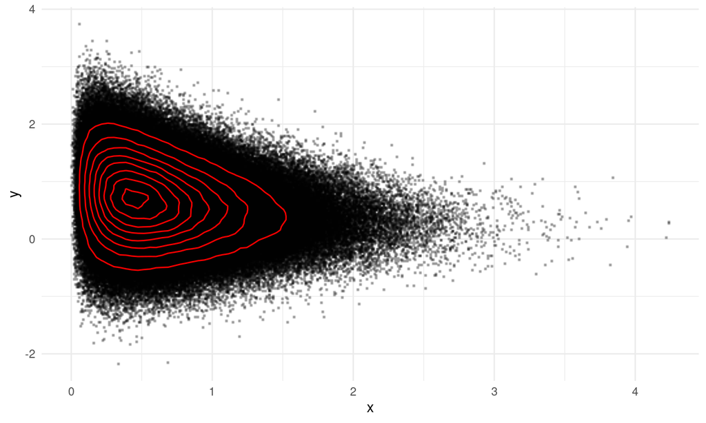

```r
ggplot(gibbs_res, aes(x,y)) +
  ggrastr::rasterise(geom_point(pch = ".", alpha = 0.4)) +
  geom_density2d(colour = "red")
```

## Sugar

- [syntactic sugar](https://en.wikipedia.org/wiki/Syntactic_sugar)

> If there’s a sugar version of the function you’re interested in, you should use it: it’ll be both expressive and well tested. Sugar functions aren’t always faster than a handwritten equivalent, but they will get faster in the future as more time is spent on optimising Rcpp. ([AdvR](http://adv-r.had.co.nz/Rcpp.html#rcpp-case-studies#sugar))
- automatic vectorized arithmetic, logical comparisons, math functions, probability distributions …
- (**but** note that vectorization here is for readability, not speed)

## Sugar example

```r
cppFunction(
"NumericVector pdistC2(double x, NumericVector ys) {
  return sqrt(pow((x - ys), 2));
}
")
pdistC2(2,-2:4)
```

```
## [1] 4 3 2 1 0 1 2
```

## libraries

- `RcppEigen` (Eigen library)
- `RcppArmadillo` ([Armadillo](http://arma.sourceforge.net/) library)

Super-simple example.

```r
library(RcppArmadillo)
cppFunction(depends="RcppArmadillo",
    "arma::mat matMult(arma::mat x, arma::mat y) {
       return (x%y);
}
")
matMult(matrix(1:4,2),matrix(1:4,2))
```

```
##      [,1] [,2]
## [1,]    1    9
## [2,]    4   16
```

## More on Armadillo

- automatic conversion from R matrix \(\leftrightarrow\) `NumericMatrix` \(\leftrightarrow\) `arma::mat` (elsewhere may need `as<arma::mat>` to convert)
- `.fill` to initialize matrices
- syntax generally MATLAB-like (!!): [table](http://arma.sourceforge.net/docs.html#syntax)
- eigenvalues/vectors; decompositions (Cholesky, QR, SVD, etc.); sparse matrices; …

## Resources

- books (Eddelbuettel 2013; Wickham 2014)
- [Rcpp on the author’s web site](http://dirk.eddelbuettel.com/code/rcpp.html)
- [quick reference guide](http://dirk.eddelbuettel.com/code/rcpp/Rcpp-quickref.pdf) (PDF)
- [Rcpp gallery](http://gallery.rcpp.org/)
  - [stochastic SIR model](http://gallery.rcpp.org/articles/epidemiological-compartment-model/)
  - [EM algorithm for probit regression](http://gallery.rcpp.org/articles/EM-algorithm-example/) (with Armadillo)
- [another basic intro to RcppArmadillo](http://q-aps.princeton.edu/sites/default/files/q-aps/files/slides_day4_am.pdf)

## Source

https://bbolker.github.io/compstatsR

[figure not shown]

## References

Bryan, Jenny. 2018. “Code Smells and Feels.” *Speaker Deck*. https://speakerdeck.com/jennybc/code-smells-and-feels.

Eddelbuettel, Dirk. 2013. *Seamless R and C++ Integration with Rcpp*. New York: Springer. https://link-springer-com.libaccess.lib.mcmaster.ca/book/10.1007/978-1-4614-6868-4.

Wickham, Hadley. 2014. *Advanced R*. 1st ed. Boca Raton, FL: Chapman; Hall/CRC. http://adv-r.had.co.nz/Rcpp.html.

———. 2019. *Advanced R*. 2nd ed. Boca Raton, FL: Chapman; Hall/CRC. http://adv-r.had.co.nz/Rcpp.html.